# (Exploring Udemy Courses Data ) by (Yusuf Yaseen)

## Preliminary Wrangling

> This data set is sample of udemy courses data set gathered by using udemy devolper api and is made of 3678 row and 12 column.

### Importing Libraries needed

```python
# import all packages and set plots to be embedded inline
import numpy as np
import pandas as pd
import matplotlib.pyplot as plt
import seaborn as sb
%matplotlib inline
base_color = sb.color_palette()[0]
import warnings
warnings.simplefilter("ignore")
```

> Loading dataset and describe its properties through the questions below.

### Gathering and assessing data

```python
df = pd.read_csv('udemy_courses.csv')
df.head()
df.loc[(df.is_paid == False),'is_paid']="free"
df.loc[(df.is_paid == True),'is_paid']="paid"
df.sample(20)
```

|  | course_id | course_title | url | is_paid | price | num_subscribers | num_reviews | num_lectures | level | content_duration | published_timestamp | subject |
| --- | --- | --- | --- | --- | --- | --- | --- | --- | --- | --- | --- | --- |
| 2934 | 1148412 | Building a eCommerce Startup in 4 Hours [Lives... | https://www.udemy.com/4-hour-startup-building-... | paid | 50 | 1114 | 8 | 23 | Beginner Level | 3.0 | 2017-04-11T00:40:01Z | Web Development |
| 311 | 725658 | FOREX : LearnTo Trade the Improved ( Advanced ... | https://www.udemy.com/forex-learnto-trade-the-... | paid | 75 | 55 | 2 | 27 | All Levels | 5.5 | 2016-01-13T03:15:11Z | Business Finance |
| 2867 | 579182 | Wordpress Essentials: Useful Plugins | https://www.udemy.com/wordpress-essentials-use... | paid | 25 | 1087 | 7 | 24 | Beginner Level | 1.0 | 2015-09-15T00:19:49Z | Web Development |
| 1568 | 518188 | An Easy Introduction to Adobe Photoshop | https://www.udemy.com/an-easy-introduction-to-... | paid | 20 | 1 | 0 | 6 | Beginner Level | 1.0 | 2015-07-07T00:14:56Z | Graphic Design |
| 1822 | 1013558 | Pure Pentatonic Power: Rock and Blues Guitar S... | https://www.udemy.com/pure-pentatonic-power-a-... | paid | 50 | 128 | 10 | 18 | All Levels | 2.0 | 2016-11-27T15:59:33Z | Musical Instruments |
| 1160 | 54677 | Revealed: Profitable Principles of Successful ... | https://www.udemy.com/revealed-profitable-secr... | paid | 25 | 1046 | 5 | 26 | All Levels | 3.0 | 2013-05-19T01:51:44Z | Business Finance |
| 3010 | 688968 | PHP with PDO - ULTIMATE Crash Course | https://www.udemy.com/php-with-pdo-ultimate-cr... | paid | 50 | 1248 | 171 | 18 | All Levels | 1.5 | 2015-12-06T23:01:34Z | Web Development |
| 2421 | 592122 | What you can learn before Piano Lessons | https://www.udemy.com/what-you-can-learn-befor... | free | 0 | 61 | 1 | 31 | Beginner Level | 1.5 | 2015-09-01T20:54:52Z | Musical Instruments |
| 3242 | 777654 | Learn what's new in PHP 7 | https://www.udemy.com/php7-new-features/ | free | 0 | 12336 | 271 | 26 | Intermediate Level | 3.5 | 2016-04-04T22:32:13Z | Web Development |
| 139 | 1198166 | Top 10 Trading Ideas in the Equities Market | https://www.udemy.com/top-10-trading-ideas-in-... | paid | 20 | 661 | 4 | 12 | All Levels | 1.0 | 2017-05-02T21:59:07Z | Business Finance |
| 993 | 236070 | Forex Harmonic Trading- With Multiple Forex Ch... | https://www.udemy.com/forex-harmonic-trading-w... | paid | 135 | 313 | 16 | 25 | All Levels | 2.5 | 2016-11-28T17:21:07Z | Business Finance |
| 3362 | 177912 | All You Need To Know About AngularJS - Trainin... | https://www.udemy.com/angularjs/ | paid | 50 | 1936 | 88 | 53 | All Levels | 5.0 | 2014-03-07T19:09:28Z | Web Development |
| 3046 | 180547 | PHP Development with the Laravel Framework | https://www.udemy.com/php-development-with-lar... | paid | 50 | 1611 | 24 | 20 | All Levels | 3.5 | 2014-03-11T20:40:48Z | Web Development |
| 659 | 722274 | The Complete Investing Guide: How to Beat Wall... | https://www.udemy.com/the-complete-investing-g... | paid | 50 | 13 | 3 | 25 | All Levels | 5.5 | 2016-06-14T19:11:45Z | Business Finance |
| 3336 | 764076 | Learn Bootstrap3 With Multi Purposes Single Pa... | https://www.udemy.com/single-page-layout-with-... | free | 0 | 4503 | 146 | 122 | All Levels | 21.0 | 2016-02-16T21:59:01Z | Web Development |
| 260 | 64739 | Professional Risk Manager (PRM) Certification:... | https://www.udemy.com/professional-risk-manage... | paid | 50 | 116 | 10 | 51 | All Levels | 24.0 | 2013-07-23T20:18:35Z | Business Finance |
| 797 | 42651 | Straddles and Strangles - Volatility moves in ... | https://www.udemy.com/straddles-and-strangles/ | paid | 60 | 775 | 54 | 11 | Expert Level | 1.5 | 2013-03-12T12:30:40Z | Business Finance |
| 667 | 361286 | Wealth Management | https://www.udemy.com/austalgroupwealth-manage... | paid | 30 | 274 | 1 | 21 | All Levels | 3.5 | 2014-12-17T14:24:15Z | Business Finance |
| 1969 | 755198 | Rockabilly Guitar For Beginners | https://www.udemy.com/rockabilly-guitar-for-be... | paid | 40 | 475 | 125 | 36 | Beginner Level | 2.0 | 2016-02-21T15:14:52Z | Musical Instruments |
| 1325 | 686430 | Curso de Corel Draw: Como Hacer Todo para tu F... | https://www.udemy.com/coreldraw-para-eventos/ | paid | 125 | 10 | 3 | 55 | Beginner Level | 2.5 | 2016-04-27T04:22:31Z | Graphic Design |

```python
# Let's see some info about columns
df.info()
```

```
<class 'pandas.core.frame.DataFrame'>
RangeIndex: 3678 entries, 0 to 3677
Data columns (total 12 columns):
 #   Column               Non-Null Count  Dtype
---  ------               --------------  -----
 0   course_id            3678 non-null   int64
 1   course_title         3678 non-null   object
 2   url                  3678 non-null   object
 3   is_paid              3678 non-null   object
 4   price                3678 non-null   int64
 5   num_subscribers      3678 non-null   int64
 6   num_reviews          3678 non-null   int64
 7   num_lectures         3678 non-null   int64
 8   level                3678 non-null   object
 9   content_duration     3678 non-null   float64
 10  published_timestamp  3678 non-null   object
 11  subject              3678 non-null   object
dtypes: float64(1), int64(5), object(6)
memory usage: 344.9+ KB
```

```python
df.shape
```

```
(3678, 12)
```

```python
# View Data Statistics
df.describe()
```

|  | course_id | price | num_subscribers | num_reviews | num_lectures | content_duration |
| --- | --- | --- | --- | --- | --- | --- |
| count | 3.678000e+03 | 3678.000000 | 3678.000000 | 3678.000000 | 3678.000000 | 3678.000000 |
| mean | 6.759720e+05 | 66.049483 | 3197.150625 | 156.259108 | 40.108755 | 4.094517 |
| std | 3.432732e+05 | 61.005755 | 9504.117010 | 935.452044 | 50.383346 | 6.053840 |
| min | 8.324000e+03 | 0.000000 | 0.000000 | 0.000000 | 0.000000 | 0.000000 |
| 25% | 4.076925e+05 | 20.000000 | 111.000000 | 4.000000 | 15.000000 | 1.000000 |
| 50% | 6.879170e+05 | 45.000000 | 911.500000 | 18.000000 | 25.000000 | 2.000000 |
| 75% | 9.613555e+05 | 95.000000 | 2546.000000 | 67.000000 | 45.750000 | 4.500000 |
| max | 1.282064e+06 | 200.000000 | 268923.000000 | 27445.000000 | 779.000000 | 78.500000 |

```python
#  now lets see duplicates in data
sum(df.duplicated())
```

```
6
```

```python
df.course_title.value_counts()
```

```
Acoustic Blues Guitar Lessons                                3
Creating an animated greeting card via Google Slides         3
Aprende a tocar el acordeón de botones                       2
MicroStation - Células                                       2
Drum Lessons For Beginners                                   2
                                                            ..
Logo Designing for Your Business in an Hour                  1
Guitar Lessons - The Modal System - Modes Essentials         1
The Day Trader: Learn to Trade The Stock Market and Forex    1
Accounting 101: Guide to Business Accounting                 1
ChatBots: Messenger ChatBot with API.AI and Node.JS          1
Name: course_title, Length: 3663, dtype: int64
```

```python
# lets see if there is null values
df.isnull().sum()
```

```
course_id              0
course_title           0
url                    0
is_paid                0
price                  0
num_subscribers        0
num_reviews            0
num_lectures           0
level                  0
content_duration       0
published_timestamp    0
subject                0
dtype: int64
```

### Cleaning Data

#### Copying data frame

```python
courses_data = df.copy()
```

#### Transform published_timestamp from object to timestamp

```python
courses_data['published_timestamp'] = pd.to_datetime(df['published_timestamp'])
```

#### Add month and year columns

```python
courses_data['year']= courses_data.published_timestamp.dt.year
courses_data['month'] = courses_data.published_timestamp.dt.month
courses_data.info()
courses_data.head()
```

```
<class 'pandas.core.frame.DataFrame'>
RangeIndex: 3678 entries, 0 to 3677
Data columns (total 14 columns):
 #   Column               Non-Null Count  Dtype
---  ------               --------------  -----
 0   course_id            3678 non-null   int64
 1   course_title         3678 non-null   object
 2   url                  3678 non-null   object
 3   is_paid              3678 non-null   object
 4   price                3678 non-null   int64
 5   num_subscribers      3678 non-null   int64
 6   num_reviews          3678 non-null   int64
 7   num_lectures         3678 non-null   int64
 8   level                3678 non-null   object
 9   content_duration     3678 non-null   float64
 10  published_timestamp  3678 non-null   datetime64[ns, UTC]
 11  subject              3678 non-null   object
 12  year                 3678 non-null   int64
 13  month                3678 non-null   int64
dtypes: datetime64[ns, UTC](1), float64(1), int64(7), object(5)
memory usage: 402.4+ KB
```

|  | course_id | course_title | url | is_paid | price | num_subscribers | num_reviews | num_lectures | level | content_duration | published_timestamp | subject | year | month |
| --- | --- | --- | --- | --- | --- | --- | --- | --- | --- | --- | --- | --- | --- | --- |
| 0 | 1070968 | Ultimate Investment Banking Course | https://www.udemy.com/ultimate-investment-bank... | paid | 200 | 2147 | 23 | 51 | All Levels | 1.5 | 2017-01-18 20:58:58+00:00 | Business Finance | 2017 | 1 |
| 1 | 1113822 | Complete GST Course & Certification - Grow You... | https://www.udemy.com/goods-and-services-tax/ | paid | 75 | 2792 | 923 | 274 | All Levels | 39.0 | 2017-03-09 16:34:20+00:00 | Business Finance | 2017 | 3 |
| 2 | 1006314 | Financial Modeling for Business Analysts and C... | https://www.udemy.com/financial-modeling-for-b... | paid | 45 | 2174 | 74 | 51 | Intermediate Level | 2.5 | 2016-12-19 19:26:30+00:00 | Business Finance | 2016 | 12 |
| 3 | 1210588 | Beginner to Pro - Financial Analysis in Excel ... | https://www.udemy.com/complete-excel-finance-c... | paid | 95 | 2451 | 11 | 36 | All Levels | 3.0 | 2017-05-30 20:07:24+00:00 | Business Finance | 2017 | 5 |
| 4 | 1011058 | How To Maximize Your Profits Trading Options | https://www.udemy.com/how-to-maximize-your-pro... | paid | 200 | 1276 | 45 | 26 | Intermediate Level | 2.0 | 2016-12-13 14:57:18+00:00 | Business Finance | 2016 | 12 |

#### See paid column

```python
# See paid columns
courses_data.is_paid.value_counts()
```

```
paid    3368
free     310
Name: is_paid, dtype: int64
```

### What is/are the main feature(s) of interest in your dataset?

> The main features is price, num_reviews of courses ,the paid courses and content_duration of each course and level of each course

### What features in the dataset do you think will help support your investigation into your feature(s) of interest?

> is_paid , price , num_subscribers , num_reviews , num_lectures , level ,content_duration

## Univariate Exploration

> Let's check the important variables distribution

#### Checking distribution of paid and free courses

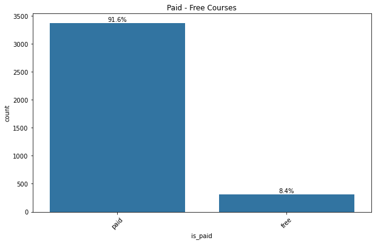

```python
plt.figure(figsize = [10, 6])

sb.countplot( data=courses_data ,x='is_paid',color = base_color);
df_count = courses_data.shape[0]
paid = courses_data['is_paid'].value_counts()
# Recalculating the type_counts just to have clarity.

# get the current tick locations and labels
locs, labels = plt.xticks(rotation=45)
plt.title("Paid - Free Courses")
# loop through each pair of locations and labels
for loc, label in zip(locs, labels):

    # get the text property for the label to get the correct count
    count = paid[label.get_text()]
    pct_string = '{:0.1f}%'.format(100*count/df_count)

    # print the annotation just below the top of the bar
    plt.text(loc, count+30, pct_string, ha = 'center', color = 'black')
```

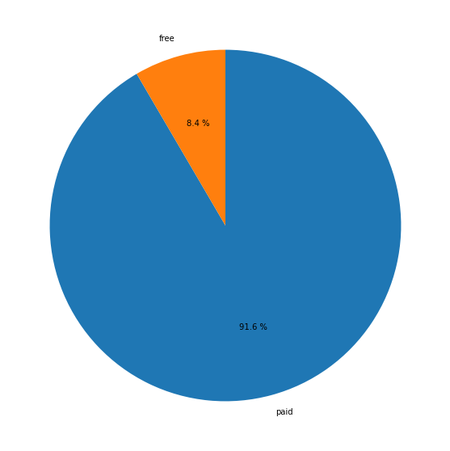

```python
sorted_counts = courses_data['is_paid'].value_counts()
plt.figure(figsize = [10, 10])

plt.pie(sorted_counts, labels = sorted_counts.index, startangle = 90 ,counterclock = False,autopct=lambda x: f"{round(x, 1)} %");
```

> we can notice that from this sample that free courses is only 8.4 % from the full distribution and the rest of courses is paid courses and present 91.6 % of the distribution

#### checking absolute Counts of each level :

```python
levels = courses_data['level'].value_counts()
levels
```

```
All Levels            1929
Beginner Level        1270
Intermediate Level     421
Expert Level            58
Name: level, dtype: int64
```

#### checking relative Counts of each level :

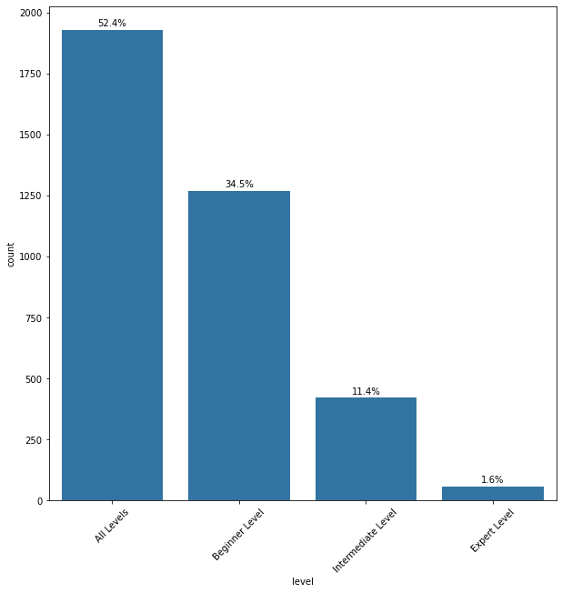

```python
plt.figure(figsize = [10, 10])

sb.countplot(data=courses_data, x='level', color=base_color, order=levels.index);
df_count = courses_data.shape[0]
# Recalculating the type_counts just to have clarity.

# get the current tick locations and labels
locs, labels = plt.xticks(rotation=45)

# loop through each pair of locations and labels
for loc, label in zip(locs, labels):

    # get the text property for the label to get the correct count
    count = levels[label.get_text()]
    pct_string = '{:0.1f}%'.format(100*count/df_count)

    # print the annotation just below the top of the bar
    plt.text(loc, count+15, pct_string, ha = 'center', color = 'black')
```

> course level distribution clearly shows that courses that is for every one is more produced to gain more money and to get bigger number of subscribers and on the other hand beginner levelk courses comes in the second place with 34.5%

#### Checking current_price variable distribution

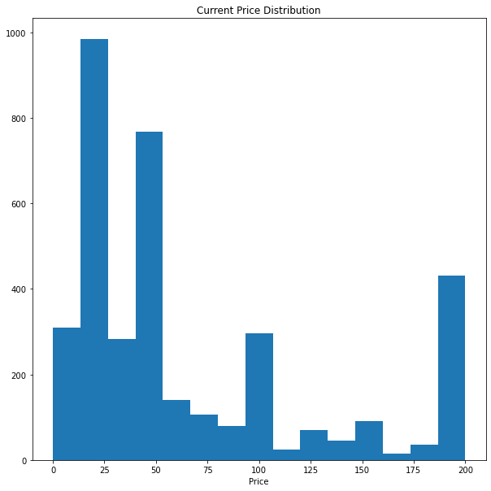

```python
plt.figure(figsize = [10, 10])

plt.title('Current Price Distribution')
plt.xlabel('Price')

plt.hist(data=courses_data ,x='price',bins = 15);
```

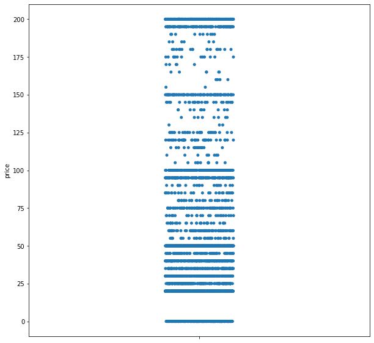

```python
plt.figure(figsize = [10, 10])
sb.stripplot(y=courses_data['price'])
```

#### Checking num_lectures variable distribution

```python
print(courses_data.num_lectures.min(),courses_data.num_lectures.max())
```

```
0 779
```

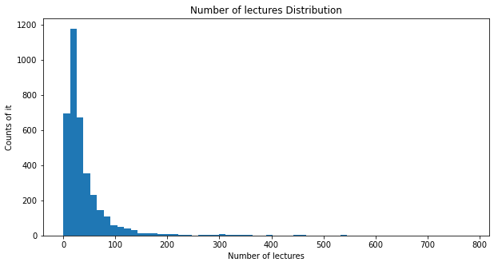

```python
# lets see courses price distribution
# Create bins with step-size
plt.figure(figsize = [10, 5])

plt.hist(data = courses_data, x = 'num_lectures', bins = 60)
plt.title('Number of lectures Distribution')
plt.xlabel('Number of lectures')
plt.ylabel('Counts of it')
# # Change seaborn plot size
```

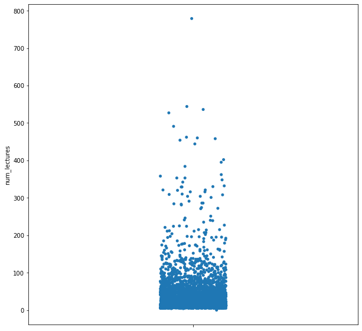

```python
plt.figure(figsize = [10, 10])
sb.stripplot(y=courses_data['num_lectures']);
```

> now now we can see that most of courses has range of 0 to 300 and some outliers so we we will remove the outliers

```
(array([-50.,   0.,  50., 100., 150., 200., 250., 300., 350.]),
 [Text(0, 0, ''),
```

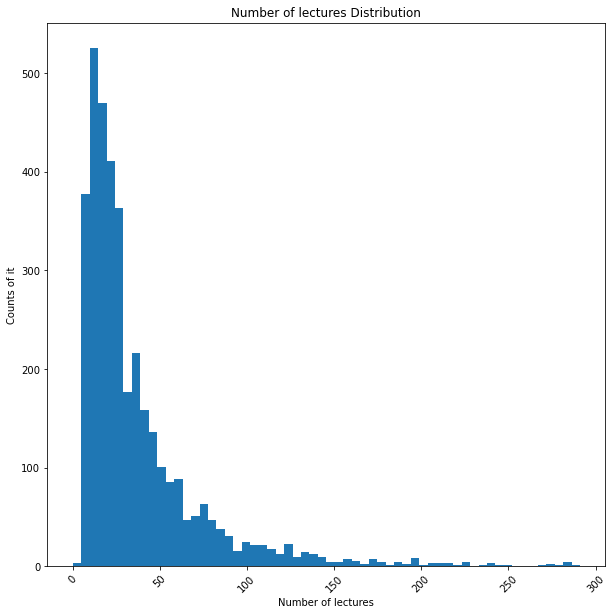

```python
# removing outliers
courses_data = courses_data[courses_data['num_lectures']<=300]
# lets see courses price distribution
# Create bins with step-size
plt.figure(figsize = [10, 10])

plt.hist(data = courses_data, x = 'num_lectures', bins = 60);
plt.title('Number of lectures Distribution')
plt.xlabel('Number of lectures')
plt.ylabel('Counts of it')
# # Change seaborn plot size
plt.xticks(rotation=45)
```

#### Checking Subjects distribution

```python
Levels_count = courses_data['subject'].value_counts()
Levels_order = Levels_count.index
Levels_count
```

```
Business Finance       1187
Web Development        1179
Musical Instruments     675
Graphic Design          603
Name: subject, dtype: int64
```

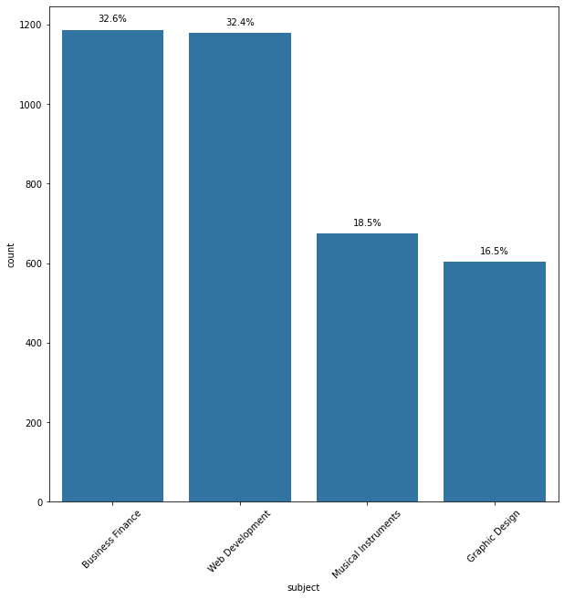

```python
Levels_count = courses_data['subject'].value_counts()
Levels_order = Levels_count.index

# Considering the same chart from the Example 1 above, print the text (proportion) BELOW the bars
plt.figure(figsize = [10, 10])

base_color = sb.color_palette()[0]
sb.countplot(data=courses_data, x='subject', color=base_color, order=Levels_order);
df_count = courses_data.shape[0]

# get the current tick locations and labels
locs, labels = plt.xticks(rotation=45)

# loop through each pair of locations and labels
for loc, label in zip(locs, labels):

    # get the text property for the label to get the correct count
    count = Levels_count[label.get_text()]
    pct_string = '{:0.1f}%'.format(100*count/df_count)

    # print the annotation just below the top of the bar
    plt.text(loc, count+20, pct_string, ha = 'center', color = 'black')
```

#### Checking num of courses created over years

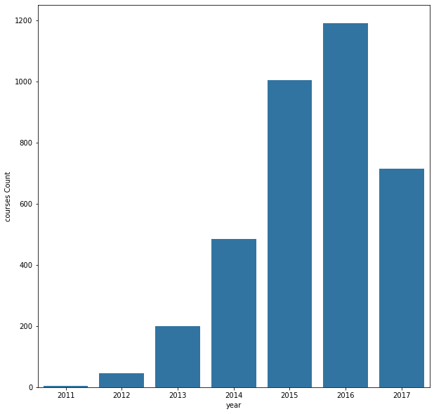

```python
plt.figure(figsize = [10, 10])

sb.countplot(data = courses_data, x = 'year', color = base_color)
# # Change seaborn plot size
plt.xlabel('year')
plt.ylabel('courses Count')
```

#### Checking num of courses created over months

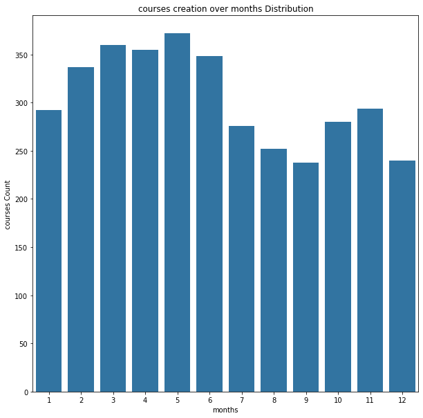

```python
plt.figure(figsize = [10, 10])

sb.countplot(data = courses_data, x = 'month', color = base_color,)
plt.title('courses creation over months Distribution')
plt.xlabel('months')
plt.ylabel('courses Count')
```

> we can see that courses creation is the greatest in may

## Bivariate Exploration

> In this section, i will investigate relationships between pairs of variables in the data.

#### Clustered bar chart in subject with the paid courses

```
(array([0, 1, 2, 3]),
 [Text(0, 0, 'Business Finance'),
```

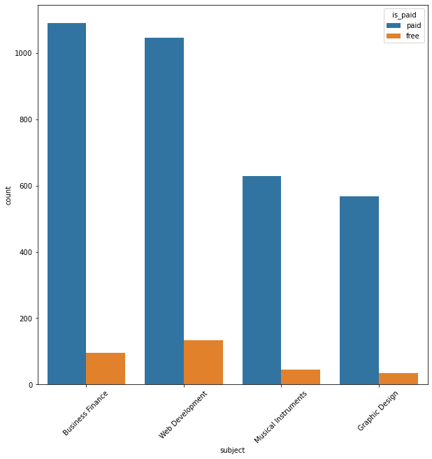

```python
plt.figure(figsize = [10, 10])

sb.countplot(x="subject", hue="is_paid", data=courses_data ,order= courses_data.subject.value_counts().index);
# Change seaborn plot size
plt.xticks(rotation=45)
```

#### Clustered bar chart in subject with the levels in it.

```
(array([0, 1, 2, 3]),
 [Text(0, 0, 'Business Finance'),
```

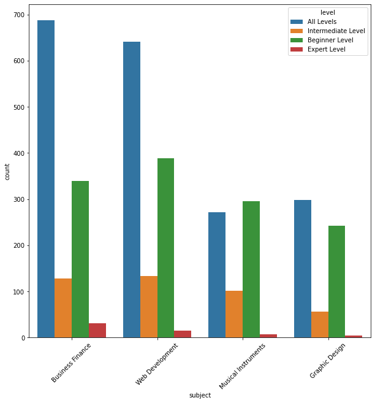

```python
plt.figure(figsize = [10, 10])

sb.countplot(x="subject", hue="level", data=courses_data ,order= courses_data.subject.value_counts().index);
# Change seaborn plot size
plt.xticks(rotation=45)
```

#### Clustered bar chart in levels with the paid courses

```
(array([   0.,  250.,  500.,  750., 1000., 1250., 1500., 1750., 2000.]),
 [Text(0, 0, ''),
```

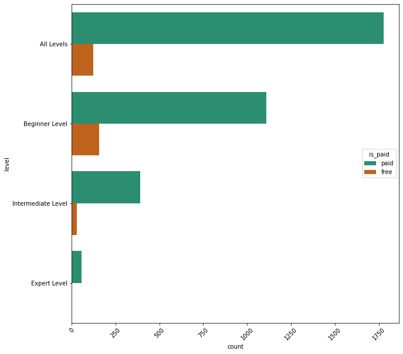

```python
plt.figure(figsize = [10, 10])

sb.countplot(y="level", hue="is_paid", data=courses_data ,order= courses_data.level.value_counts().index,palette = "Dark2");
# Change seaborn plot size
plt.xticks(rotation=45)
```

```python
prices = courses_data.groupby(['subject'])['price'].sum()
prices
```

```
subject
Business Finance       80510
Graphic Design         34870
Musical Instruments    33205
Web Development        88940
Name: price, dtype: int64
```

```
(array([     0.,  20000.,  40000.,  60000.,  80000., 100000.]),
 [Text(0, 0, ''),
```

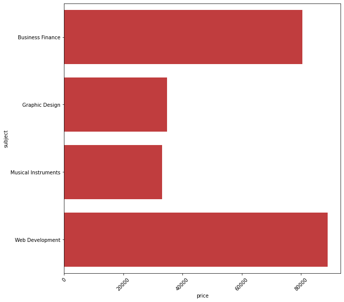

```python
plt.figure(figsize = [10, 10])

sb.barplot(y=prices.index, x=prices ,color = sb.color_palette()[3],errwidth  = 0)
plt.xticks(rotation=45)
# Change seaborn plot size
```

```python
num = courses_data.groupby(['subject'])['num_subscribers'].sum()
num
```

```
subject
Business Finance       1854497
Graphic Design         1063148
Musical Instruments     738115
Web Development        7535812
Name: num_subscribers, dtype: int64
```

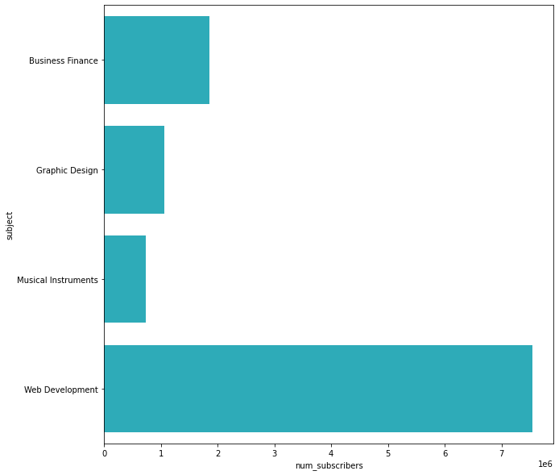

```python
plt.figure(figsize = [10, 10])

sb.barplot(y=num.index, x=num ,color = sb.color_palette()[9],errwidth  = 0)
# Change seaborn plot size
```

```python
allLecturesInSubjects = courses_data.groupby(['subject'])['num_lectures'].sum()
allLecturesInSubjects
```

```
subject
Business Finance       35275
Graphic Design         19329
Musical Instruments    24432
Web Development        55282
Name: num_lectures, dtype: int64
```

```
(array([    0., 10000., 20000., 30000., 40000., 50000., 60000.]),
 [Text(0, 0, ''),
```

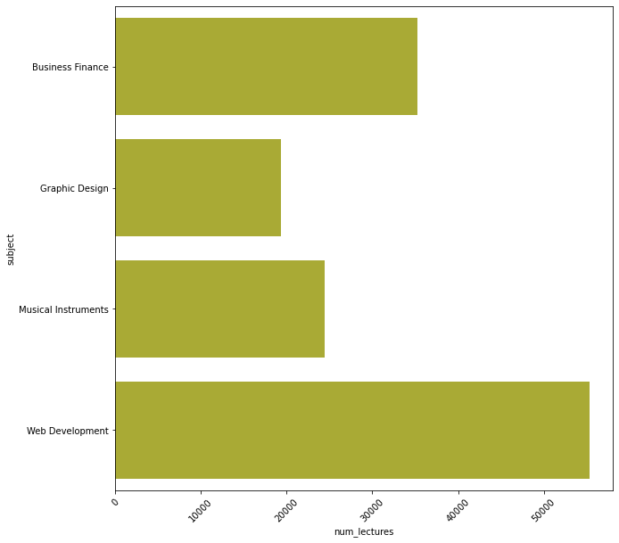

```python
plt.figure(figsize = [10, 10])

sb.barplot(y=allLecturesInSubjects.index, x=allLecturesInSubjects ,color = sb.color_palette()[8],errwidth  = 0)
plt.xticks(rotation=45)
# Change seaborn plot size
```

```python
paid_subscribers = courses_data.groupby(['is_paid'])['num_subscribers'].sum()
paid_subscribers
```

```
is_paid
free    3575525
paid    7616047
Name: num_subscribers, dtype: int64
```

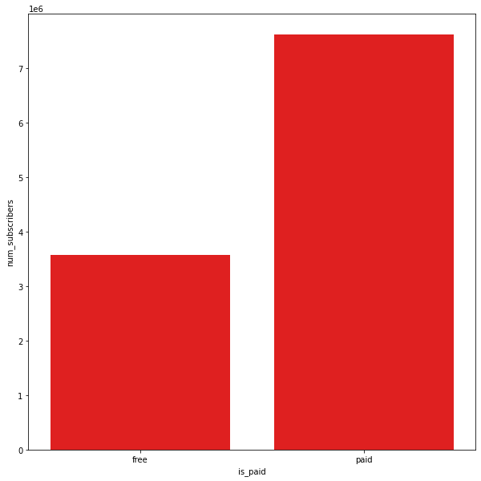

```python
plt.figure(figsize = [10, 10])

sb.barplot(x=paid_subscribers.index, y=paid_subscribers ,color = 'r',errwidth  = 0)
# Change seaborn plot size
```

```python
level_subscribers = courses_data.groupby(['level'])['num_subscribers'].sum()
level_subscribers
```

```
level
All Levels            6376410
Beginner Level        4024314
Expert Level            50196
Intermediate Level     740652
Name: num_subscribers, dtype: int64
```

```
(array([0, 1, 2, 3]),
 [Text(0, 0, 'All Levels'),
```

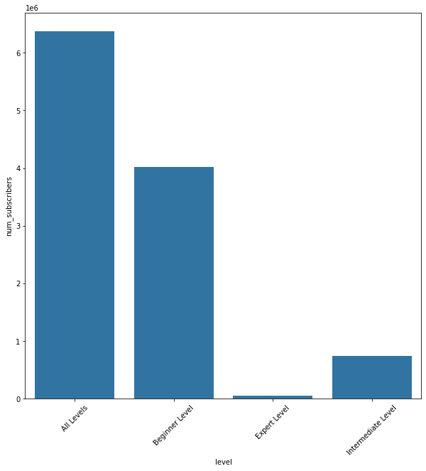

```python
plt.figure(figsize = [10, 10])

sb.barplot(x=level_subscribers.index, y=level_subscribers ,color = sb.color_palette()[0],errwidth  = 0)
plt.xticks(rotation=45)
# Change seaborn plot size
```

```python
level_price = courses_data.groupby(['level'])['price'].sum()
level_price
```

```
level
All Levels            136055
Beginner Level         70315
Expert Level            5285
Intermediate Level     25870
Name: price, dtype: int64
```

```
(array([     0.,  20000.,  40000.,  60000.,  80000., 100000., 120000.,
        140000., 160000.]),
 [Text(0, 0, ''),
```

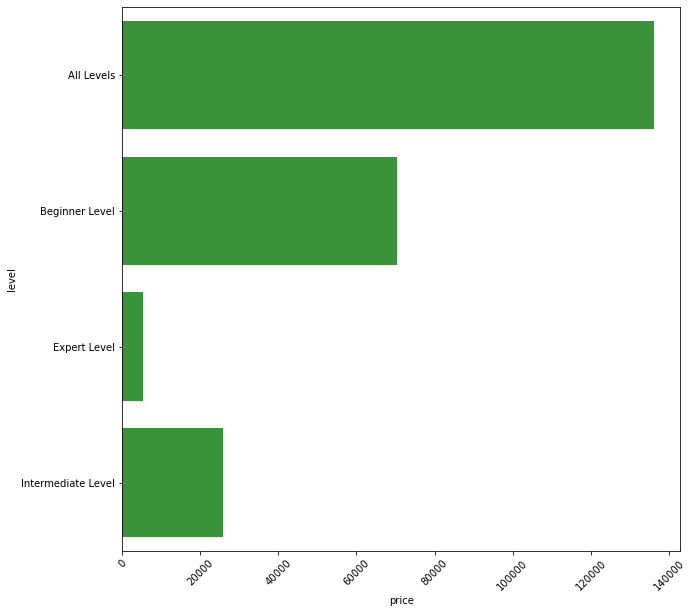

```python
plt.figure(figsize = [10, 10])

sb.barplot(y=level_price.index, x=level_price ,color = sb.color_palette()[2],errwidth  = 0)
plt.xticks(rotation=45)
# Change seaborn plot size
```

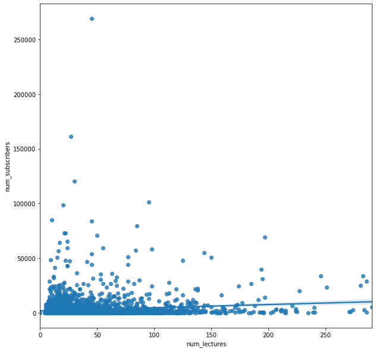

```python
plt.figure(figsize = [10, 10])

# plt.scatter(data = courses_data, x = 'num_lectures', y = 'num_subscribers');
sb.regplot(data = courses_data, x = 'num_lectures', y = 'num_subscribers');
```

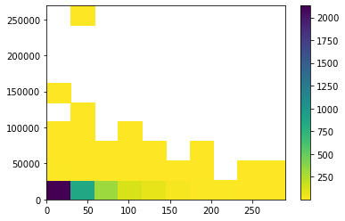

```python
# Specify bin edges
# bins_x = np.arange(0, 779+50, 50)
# bins_y = np.arange(0, 268923+50000, 20000)
plt.hist2d(data = courses_data, x = 'num_lectures', y = 'num_subscribers', cmin=0.5, cmap='viridis_r')
plt.colorbar()
```

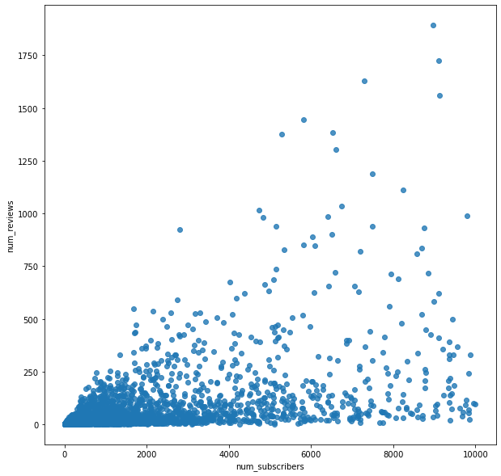

```python
plt.figure(figsize = [10, 10])

sb.regplot(data = courses_data[courses_data['num_subscribers'] < 10000], x = 'num_subscribers', y = 'num_reviews', fit_reg = False);
```

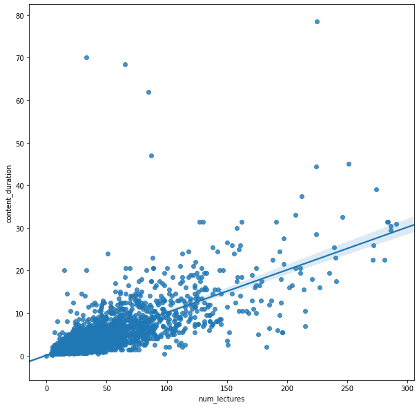

```python
plt.figure(figsize = [10, 10])

sb.regplot(data = courses_data, x = 'num_lectures', y = 'content_duration', truncate=False);
```

### Talk about some of the relationships you observed in this part of the investigation. How did the feature(s) of interest vary with other features in the dataset?

> there is a strong relation between number of lectures and content duration

> there is a strong relation between number of subscribers and number of reviews as each courses subscriber can review course

### Did you observe any interesting relationships between the other features (not the main feature(s) of interest)?

> no

## Multivariate Exploration

> lets see relations connects more than one variable

#### Check relation between course level ,number of subscibers and num_reviews

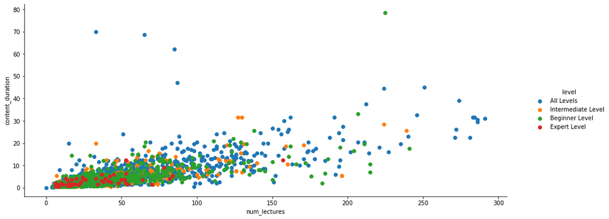

```python
g = sb.FacetGrid(data = courses_data, hue = 'level',size=10 )
g.map(plt.scatter, 'num_lectures','content_duration')
g.add_legend()
fig = plt.gcf()
fig.set_size_inches(15,5)
```

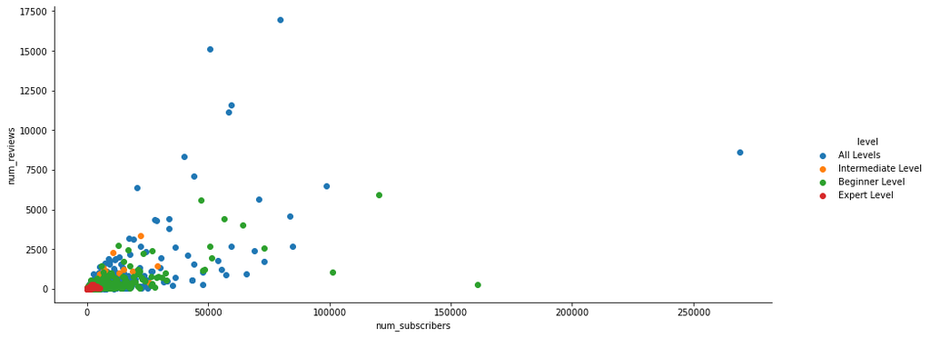

```python
g = sb.FacetGrid(data = courses_data, hue = 'level',size=10 )
g.map(plt.scatter, 'num_subscribers', 'num_reviews')
g.add_legend()
fig = plt.gcf()
fig.set_size_inches(15,5)
```

> as seen before number of expert level courses that is produced is small so expert level subscribers are few on the other hand courses for all and beginner levels has the most of the subscribers

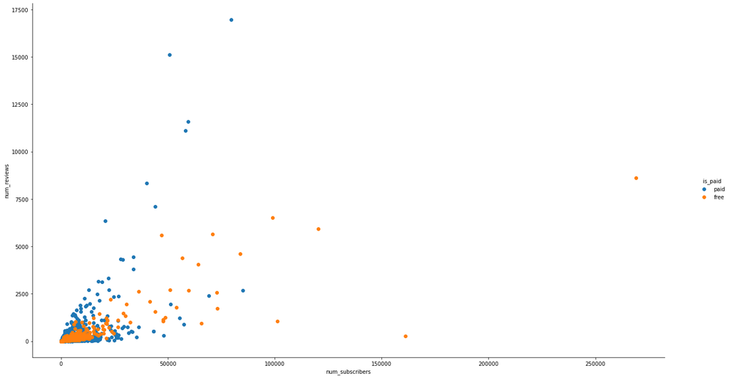

```python
g = sb.FacetGrid(data = courses_data, hue = 'is_paid',size=10 )
g.map(plt.scatter, 'num_subscribers', 'num_reviews')
g.add_legend()
fig = plt.gcf()
fig.set_size_inches(20,10)
```